# Exercise 5

```r
#As mentioned above, the Lenovo brand shows a higher average weight compared to all the other brands. As for the lowest weight, it's easy to see from the chart that the brand with the lowest average weight in this case is LG.
```

[output not shown]

6. Create a ranking of the 5 most expensive smartphones from the Huawei brand

```r
names(smart) #I resort to names() to inspect the variable names available for further use
```

```
##  [1] "phone_name"        "brand"             "os"
##  [4] "inches"            "resolution"        "battery"
##  [7] "battery_type"      "announcement_date" "video_720p"
## [10] "video_1080p"       "video_4K"          "video_8K"
## [13] "video_30fps"       "video_60fps"       "video_120fps"
## [16] "video_240fps"      "video_480fps"      "video_960fps"
## [19] "ram_GB"            "weight_g"          "storage_GB"
## [22] "price_USD"
```

```r
library("dplyr") #This library introduces a syntax for data manipulation in R, including functions like filter()

price <- smart %>% filter(brand=="Huawei") %>% select(phone_name, brand, price_USD) %>% group_by(phone_name) %>% arrange(desc(price_USD))
price <- price[1:5,] #In this way, I limit my analysis to the 5 most expensive phones; the order to observe these rows in descending fashion was set using arrange(desc())
price
```

```
## # A tibble: 5 × 3
## # Groups:   phone_name [5]
##   phone_name brand  price_USD
##   <fct>      <fct>      <dbl>
## 1 P40 4G     Huawei     2300
## 2 nova 6 5G  Huawei     2150
## 3 Mate Xs 2  Huawei     1996.
## 4 P40 lite   Huawei     1950
## 5 nova 5z    Huawei     1700
```

7. It is assumed that whether a smartphone supports 8k video recording (variable video_8k) affects the final price (variable price.USD.). Represent the relationship between the variables and comment (Hint: video_8k is a categorical variable).

```r
names(smart) #For price.USD., which I slightly modified earlier
```

```
##  [1] "phone_name"        "brand"             "os"
##  [4] "inches"            "resolution"        "battery"
##  [7] "battery_type"      "announcement_date" "video_720p"
## [10] "video_1080p"       "video_4K"          "video_8K"
## [13] "video_30fps"       "video_60fps"       "video_120fps"
## [16] "video_240fps"      "video_480fps"      "video_960fps"
## [19] "ram_GB"            "weight_g"          "storage_GB"
## [22] "price_USD"
```

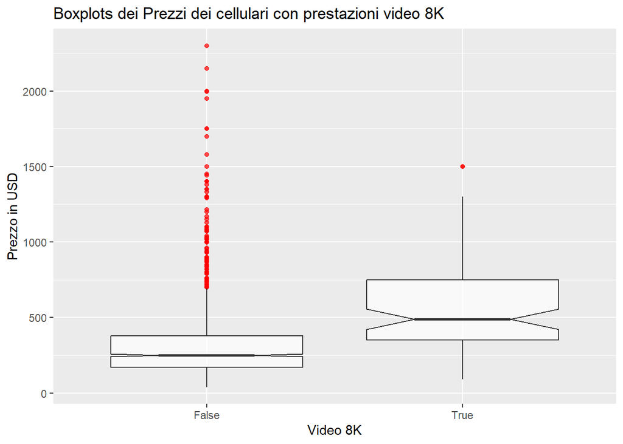

```r
#Here I proceed with a graphical representation of bivariate analysis for mixed variables (cardinal and categorical). I therefore use boxplots to compare the joint distribution of the two variables and to check for possible correlations
smart %>% ggplot(aes(x = video_8K, y = price_USD)) +
  geom_boxplot(notch = T,
               outlier.colour = "red"
               , alpha = 0.7) +
               labs(title="Boxplots dei Prezzi dei cellulari con prestazioni video 8K" ,x='Video 8K', y='Prezzo in USD')
```

```r
#It is interesting to note that the presence or absence of 8K video recording capability in a phone appears to influence its price, as the values of the price_USD variable clearly show that the price distribution for phones supporting 8K video starts at higher values and extends toward even higher ones. In fact, the boxplot for TRUE is higher than the one for FALSE.
#This suggests that the presence or absence of 8K video performance in a phone likely affects its price.

#Even more interesting is the paradox between values clustered around the central part of the distribution and those located in the more extreme areas of the boxplot. In this case, the boxplots are reversed.
#For FALSE, prices are clearly concentrated around average values, while in the case of TRUE, prices vary—and they start from higher values compared to FALSE, reaching even higher levels.
#The most interesting point of all is the presence of outliers in FALSE. Apparently, there are several cases of prices so high that they fall outside the boxplot distribution due to being too extreme—yet they reach significantly higher peaks than the prices observed in TRUE.
```

8. Try to replicate the visualization using only smartphones that cost more than $500. Provide commentary.

```r
smart$price_USD
```

[output not shown]

[output cut: 174 more lines]

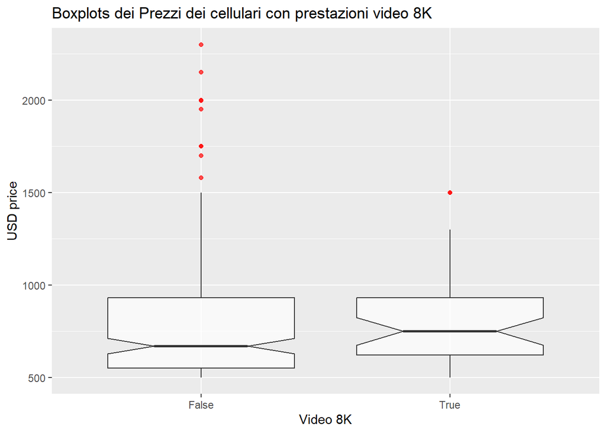

```r
smart %>% filter(price_USD>= 500)  %>%
  ggplot(aes(x = video_8K, y = price_USD)) +
  geom_boxplot(notch = T,
               outlier.colour = "red"
               , alpha = 0.7) +
               labs(title="Boxplots dei Prezzi dei cellulari con prestazioni video 8K" ,x='Video 8K', y='USD price')
```

```r
#Through a filtered representation starting from 500 USD, the boxplot distribution now allows us to take a closer look at the price distribution by 8K video categories.
#There are some differences compared to before—namely, in this case, prices for TRUE don’t necessarily reach higher peaks than FALSE, but they are definitely more concentrated around those higher values and start from higher minimums.
#Another interesting change lies in the distribution variability: in the case of TRUE, this makes sense, as the prices start from higher levels compared to FALSE. However, compared to the previous analysis, this boxplot now seems to level off around the same upper range as FALSE, which instead appears more variable, both in terms of low and high prices.

#Therefore, I would argue that the presence or absence of 8K video performance in a smartphone influences its price in terms of variability: apparently, the absence of this feature allows for both much lower and much higher prices, while when the feature is present, prices are more likely to cluster around consistently high values.
```